# ECM-2 seminar8 ARIMA

https://habr.com/ru/post/207160/

https://robjhyndman.com/hyndsight/ljung-box-test/

```python
import numpy as np
import pandas as pd
import time
import tqdm
import os
import matplotlib
%matplotlib inline
import matplotlib.pyplot as plt
from statsmodels.graphics import tsaplots
from statsmodels.tsa import stattools, arima_model # пакет для работы с временными рядами
import statsmodels.api as sm
import warnings
warnings.filterwarnings('ignore')
```

```python
matplotlib.rcParams['figure.figsize'] = (8, 8)
```

### Задача 1

Имеются ежеквартальные данные о реальном ВВП США с первого квартала 1947 года. Необходимо оценить порядок интегрированности ряда.

```python
gdp = pd.read_excel('/Users/anton.andreytsev/Desktop/real_gdp_usa.xlsx')
```

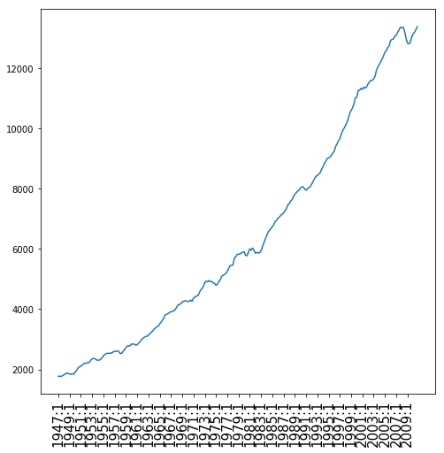

```python
plt.plot(gdp.gdp);
plt.xticks(np.arange(0, gdp.gdp.shape[0], 8), gdp.date.values[np.arange(0, gdp.gdp.shape[0], 8)], rotation=90, size=15);
```

Ряд явно не стационарный, посмотрим на его первые разности

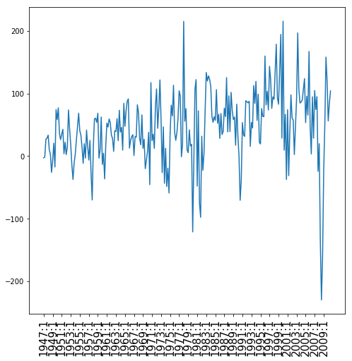

```python
dif = np.diff(gdp.gdp)
plt.plot(dif);
plt.xticks(np.arange(0, dif.shape[0], 8), gdp.date.values[np.arange(0, dif.shape[0], 8)], rotation=90, size=15);
```

Протестируем первые разности на стационарность с помощью тестов KPSS и Дики-Фулера

```python
print('Augmented Dickey-Fuller p-value:', stattools.adfuller(dif, autolag='t-stat', regression='c')[1])
```

```
Augmented Dickey-Fuller p-value: 0.03813296185255117
```

На 1% уровне значимости ряд $\Delta y_{t}$ не является стационарным

```python
print('Augmented Dickey-Fuller p-value:', stattools.adfuller(dif, autolag='t-stat', regression='ct')[1])
```

```
Augmented Dickey-Fuller p-value: 7.733780225736908e-05
```

Но он является тренд-стационарным

```python
print('KPSS p-value:', stattools.kpss(dif, regression='c')[1])
```

```
KPSS p-value: 0.011705779256350676
```

Принимаем гипотезу о том, что ряд $\Delta y_{t}$ является стационарным, а следовательно $y_{t} \in I(1)$ (интегрированный первого порядка)

### Задача 2

Исходный файл с данными: ppp_csv.csv Lnit — log price index italy, lnfr — log price index france, lnx — log exchange rate france/italy. Имеется информация о динамике уровней потребительских цен во Франции и Италии, а также о номинальном обменном валютном курсе (итальянской лиры к французском франку) за период с января 1981 года по июнь 1996 года. (а) Сформулируйте гипотезу паритета покупательной способности в терминах имеющихся данных. (б) Протестируйте выполнение этой гипотезы применительно к Италии и Франции, сгенерировав соответствующий временной ряд и протестировав его на стационарность.

```python
dat = pd.read_csv('/Users/anton.andreytsev/Desktop/ppp.csv')
dat.columns = [i.lower() for i in dat.columns]
```

```python
dat.head()
```

|  | obs | cpifr | cpiit | lnfr | lnit | lnp | lnx |
| --- | --- | --- | --- | --- | --- | --- | --- |
| 0 | 1981M01 | 57.8451 | 43.5 | 4.057769 | 3.772761 | -0.285008 | 5.331368 |
| 1 | 1981M02 | 58.3893 | 44.3 | 4.067133 | 3.790985 | -0.276148 | 5.325063 |
| 2 | 1981M03 | 58.9334 | 45.0 | 4.076408 | 3.806662 | -0.269746 | 5.354162 |
| 3 | 1981M04 | 59.7497 | 45.6 | 4.090164 | 3.819908 | -0.270256 | 5.352268 |
| 4 | 1981M05 | 60.2939 | 46.3 | 4.099231 | 3.835142 | -0.264089 | 5.342614 |

```python
dat['year'] = dat.obs.apply(lambda x: int(x.split('M')[0]))
dat['month'] = dat.obs.apply(lambda x: int(x.split('M')[1]))
del dat['obs']
```

```python
dat.head()
```

|  | cpifr | cpiit | lnfr | lnit | lnp | lnx | year | month |
| --- | --- | --- | --- | --- | --- | --- | --- | --- |
| 0 | 57.8451 | 43.5 | 4.057769 | 3.772761 | -0.285008 | 5.331368 | 1981 | 1 |
| 1 | 58.3893 | 44.3 | 4.067133 | 3.790985 | -0.276148 | 5.325063 | 1981 | 2 |
| 2 | 58.9334 | 45.0 | 4.076408 | 3.806662 | -0.269746 | 5.354162 | 1981 | 3 |
| 3 | 59.7497 | 45.6 | 4.090164 | 3.819908 | -0.270256 | 5.352268 | 1981 | 4 |
| 4 | 60.2939 | 46.3 | 4.099231 | 3.835142 | -0.264089 | 5.342614 | 1981 | 5 |

Гипотезу паритета покупательной способности можно сформулировать следующим образом: $\frac{PriceIndex_{france}}{PriceIndex_{italy}} \approx \frac{1}{E_{france/italy}}$, где $E_{france/italy}$ - обменный курс между Францией и Италией (стоимость единицы Французской валюты, измеренной в Итальянской валюте). Отсюда следует, что $\log PriceIndex_{france} - \log PriceIndex_{italy} + \log E_{france/italy} \approx 0$. Значит последний ряд должен быть стационарным.

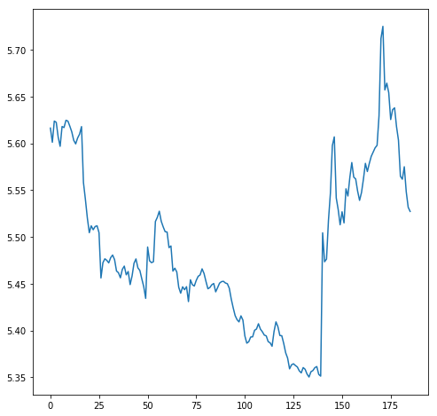

```python
plt.plot(dat.lnx + dat.lnfr - dat.lnit);
```

Невооружённым глазом видно, что это ряд не является стационарным. Однако, проведём формальные тесты

```python
print('Augmented Dickey-Fuller p-value:', stattools.adfuller(dat.lnx + dat.lnfr - dat.lnit, autolag='t-stat', regression='c')[1])
```

```
Augmented Dickey-Fuller p-value: 0.31824416600932903
```

Принимаем гипотезу о том, что ряд не является стационарным и соответственно для Италии и Франции не выполняется гипотеза ППС.

### Задача 3

Для каждого из представленных в файле ARIMA_example временных рядов подберите модель ARIMA, наилучшим образом описывающую его динамику.

Методология Бокса — Дженкинса 1. Определение порядка интегрированности ряда и переход к стационарным разностям 1. Тестируем ряд на стационарность, используя тесты 2. Если ряд оказался стационарным, то переходим к шагу 2. Если нет — то переходим к разностям ряда и снова тестируем стационарность 2. Анализ автокорреляционной функции и частной автокорреляционной функции Процесс AR(p): ACF бесконечна по протяженности и только в пределе при 𝑘 → ∞ сходится к нулю PACF равна (или близка) к нулю для лагов, больших, чем p Процесс MA(q): ACF равна (или близка) к нулю для лагов, больших, чем q. PACF бесконечна по протяженности и только в пределе при 𝑘 → ∞ сходится к нулю 3. Оценивание и проверка адекватности модели 1. Значимость коэффициентов модели 2. Анализ остатков модели (Тестирование отсутствия автокорреляции: Бокса — Пирса, Льюинга — Бокса) 3. Информационные критерии (BIC, AIC) 4. Прогнозирование

```python
dat = pd.read_excel('/Users/anton.andreytsev/Downloads/ARIMA_example.xlsx')
```

```python
dat.head()
```

|  | y1 | y2 | y3 |
| --- | --- | --- | --- |
| 0 | 19.916475 | 5.007638 | 1.000000 |
| 1 | 19.980078 | 4.983601 | 0.899422 |
| 2 | 19.857470 | 5.024198 | 0.750124 |
| 3 | 19.953421 | 5.055578 | 0.802100 |
| 4 | 20.114684 | 5.214623 | 0.637604 |

Определим побочную функция для визуализации ряда:

```python
def show_acf_pacf(y, lags_number=20):
    plt.figure(figsize=(20, 5))
    plt.plot(y)
    plt.show()
    plt.figure(figsize=(20, 5))
    tsaplots.plot_acf(y, ax=plt.subplot(1,2,1));
    plt.subplot(1,2,1).set_xlim(0, lags_number);
    plt.subplot(1,2,1).set_ylim(-0.7, 0.7);
    tsaplots.plot_pacf(y, ax=plt.subplot(1,2,2));
    plt.subplot(1,2,2).set_xlim(0, lags_number);
    plt.subplot(1,2,2).set_ylim(-0.7, 0.7);
```

1) $y_{1} \in$ Arima(p, k, q)

Проверим ряд на стационарность

```python
print('Augmented Dickey-Fuller p-value:', stattools.adfuller(dat.y1, autolag='t-stat', regression='c')[1])
```

```
Augmented Dickey-Fuller p-value: 0.00022633199622224952
```

Ряд стационарный, значит он интегрированный нулевого порядка и значит k = 0, перейдём к определению параметров p и q

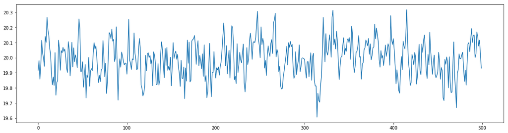

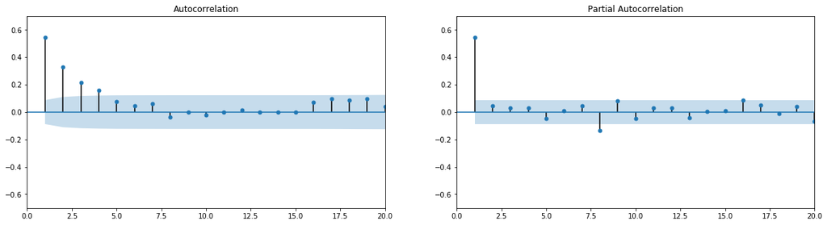

```python
show_acf_pacf(dat.y1, lags_number=20)
```

Скорее всего перед нами AR(1)

```python
model_y1 = sm.tsa.statespace.SARIMAX(dat.y1, order=(1, 0, 0)).fit()
print(model_y1.summary())
```

```
                           Statespace Model Results
==============================================================================
Dep. Variable:                     y1   No. Observations:                  500
Model:               SARIMAX(1, 0, 0)   Log Likelihood                 373.564
Date:                Fri, 12 Apr 2019   AIC                           -743.128
Time:                        14:00:06   BIC                           -734.699
Sample:                             0   HQIC                          -739.820
                                - 500
Covariance Type:                  opg
==============================================================================
                 coef    std err          z      P>|z|      [0.025      0.975]
------------------------------------------------------------------------------
ar.L1          1.0000      0.000   5069.290      0.000       1.000       1.000
sigma2         0.0129      0.001     14.669      0.000       0.011       0.015
===================================================================================
Ljung-Box (Q):                      101.25   Jarque-Bera (JB):                 1.69
Prob(Q):                              0.00   Prob(JB):                         0.43
Heteroskedasticity (H):               0.79   Skew:                             0.03
Prob(H) (two-sided):                  0.12   Kurtosis:                         2.72
===================================================================================

Warnings:
[1] Covariance matrix calculated using the outer product of gradients (complex-step).
```

Убедимся в том, что подобрали адекватную модель

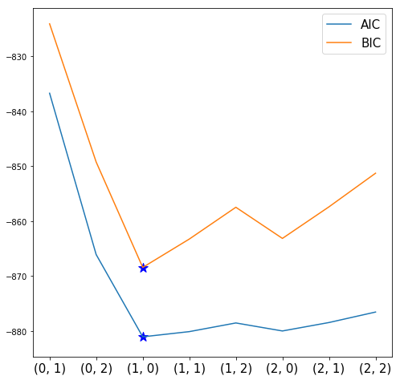

```python
aic_results = []
bic_results = []
params_ = []
for i in itertools.product(range(3), range(3)):
    if i != (0, 0):
        _ = arima_model.ARIMA(dat.y1, order=(i[0], 0, i[1])).fit()
        params_.append(i)
        aic_results.append(_.aic)
        bic_results.append(_.bic)

plt.plot(aic_results, label='AIC')
plt.plot(bic_results, label='BIC')
plt.scatter(np.argmin(bic_results), np.min(bic_results), marker='*', s=150, color='blue')
plt.scatter(np.argmin(aic_results), np.min(aic_results), marker='*', s=150, color='blue')
plt.legend(fontsize=15)
plt.xticks(range(len(params_)), params_, fontsize=15);
```

AIC и BIC для AR(1) самые маленькие

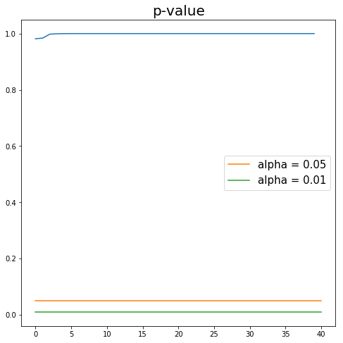

```python
q_test = stattools.acf(model_y1.resid, qstat=True)[-1]  # Q статистика Льюинга-Бокса
plt.plot(q_test)
plt.plot([0, len(q_test)], [0.05, 0.05], label='alpha = 0.05')
plt.plot([0, len(q_test)], [0.01, 0.01], label='alpha = 0.01')
plt.title('p-value', fontsize=20)
plt.legend(fontsize=15);
```

Наконец, рассмотрим как наша модель описывает динамику временного ряда

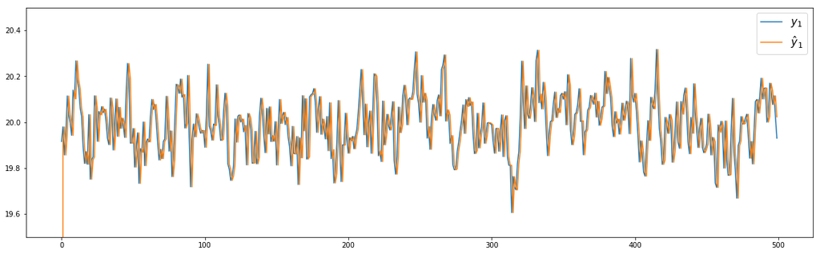

```python
plt.figure(figsize=(20, 6))
plt.plot(dat.y1, label='$y_{1}$')
plt.plot(model_y1.predict(), label='$\hat y_{1}$')
plt.ylim(19.5, 20.5)
plt.legend(fontsize=15);
```

2) $y_{2} \in$ Arima(p, k, q)

```python
print('Augmented Dickey-Fuller p-value:', stattools.adfuller(dat.y2, autolag='t-stat', regression='c')[1])
```

```
Augmented Dickey-Fuller p-value: 3.173764107685141e-27
```

Ряд стационарный, значит он интегрированный нулевого порядка и значит k = 0, перейдём к определению параметров p и q

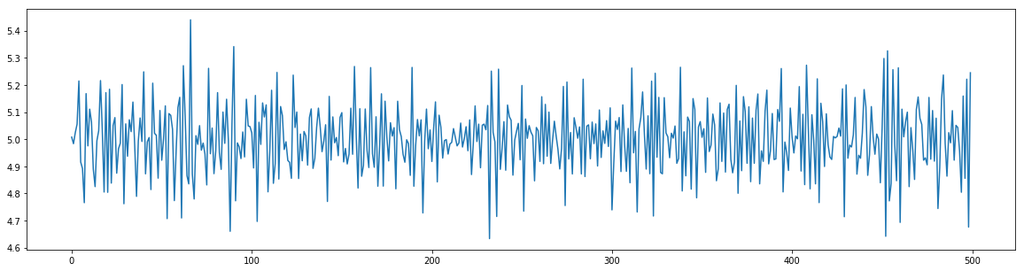

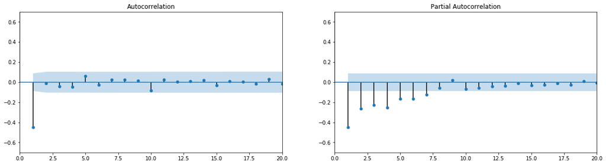

```python
show_acf_pacf(dat.y2, lags_number=20)
```

Ряд похож на MA(1)

```python
model_y2 = arima_model.ARIMA(dat.y2, order=(0, 0, 1)).fit()
print(model_y2.summary())
```

```
                              ARMA Model Results
==============================================================================
Dep. Variable:                     y2   No. Observations:                  500
Model:                     ARMA(0, 1)   Log Likelihood                 432.419
Method:                       css-mle   S.D. of innovations              0.102
Date:                Fri, 12 Apr 2019   AIC                           -858.838
Time:                        14:03:00   BIC                           -846.194
Sample:                             0   HQIC                          -853.876

==============================================================================
                 coef    std err          z      P>|z|      [0.025      0.975]
------------------------------------------------------------------------------
const          5.0009      0.001   6391.700      0.000       4.999       5.002
ma.L1.y2      -0.8298      0.024    -34.461      0.000      -0.877      -0.783
                                    Roots
=============================================================================
                  Real          Imaginary           Modulus         Frequency
-----------------------------------------------------------------------------
MA.1            1.2051           +0.0000j            1.2051            0.0000
-----------------------------------------------------------------------------
```

```python
model_y2_sar = sm.tsa.statespace.SARIMAX(dat.y2, order=(0, 0, 1)).fit()
print(model_y2_sar.summary())
```

```
                           Statespace Model Results
==============================================================================
Dep. Variable:                     y2   No. Observations:                  500
Model:               SARIMAX(0, 0, 1)   Log Likelihood               -1190.351
Date:                Fri, 12 Apr 2019   AIC                           2384.702
Time:                        14:03:51   BIC                           2393.131
Sample:                             0   HQIC                          2388.009
                                - 500
Covariance Type:                  opg
==============================================================================
                 coef    std err          z      P>|z|      [0.025      0.975]
------------------------------------------------------------------------------
ma.L1          0.9611      0.017     57.600      0.000       0.928       0.994
sigma2         6.8099      1.903      3.578      0.000       3.080      10.540
===================================================================================
Ljung-Box (Q):                     5023.78   Jarque-Bera (JB):                 7.77
Prob(Q):                              0.00   Prob(JB):                         0.02
Heteroskedasticity (H):               0.98   Skew:                             0.01
Prob(H) (two-sided):                  0.91   Kurtosis:                         2.39
===================================================================================

Warnings:
[1] Covariance matrix calculated using the outer product of gradients (complex-step).
```

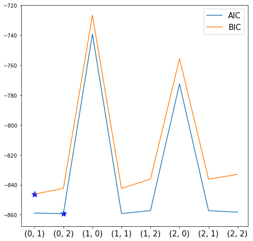

```python
aic_results = []
bic_results = []
params_ = []
for i in itertools.product(range(3), range(3)):
    if i != (0, 0):
        _ = arima_model.ARIMA(dat.y2, order=(i[0], 0, i[1])).fit()
        params_.append(i)
        aic_results.append(_.aic)
        bic_results.append(_.bic)

plt.plot(aic_results, label='AIC')
plt.plot(bic_results, label='BIC')
plt.scatter(np.argmin(bic_results), np.min(bic_results), marker='*', s=150, color='blue')
plt.scatter(np.argmin(aic_results), np.min(aic_results), marker='*', s=150, color='blue')
plt.legend(fontsize=15)
plt.xticks(range(len(params_)), params_, fontsize=15);
```

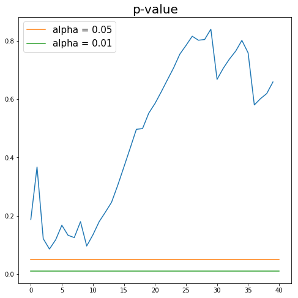

```python
q_test = stattools.acf(model_y2.resid, qstat=True)[-1]  # Q статистика Льюинга-Бокса
plt.plot(q_test)
plt.plot([0, len(q_test)], [0.05, 0.05], label='alpha = 0.05')
plt.plot([0, len(q_test)], [0.01, 0.01], label='alpha = 0.01')
plt.title('p-value', fontsize=20)
plt.legend(fontsize=15);
```

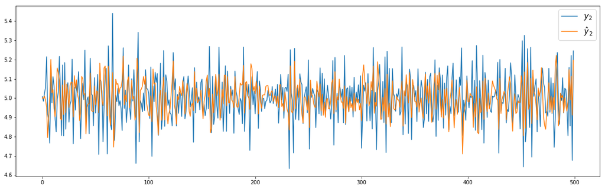

```python
plt.figure(figsize=(20, 6))
plt.plot(dat.y2, label='$y_{2}$')
plt.plot(model_y2.predict(), label='$\hat y_{2}$')
plt.legend(fontsize=15);
```

3) $y_{3} \in$ Arima(p, k, q)

```
Text(0.5,1,'$\\Delta y_{3}$')
```

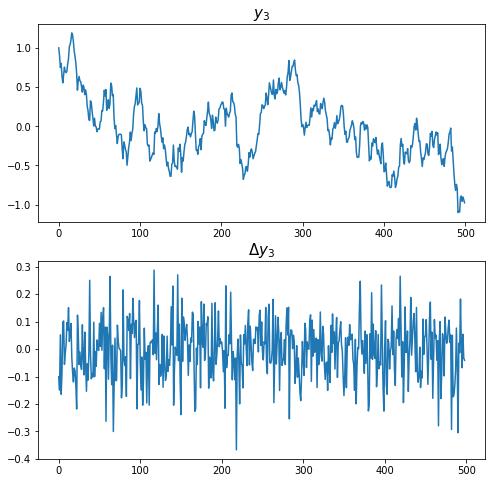

```python
fig, axes = plt.subplots(nrows=2, ncols=1)
plt.figure(figsize=(50, 6))
axes[0].plot(dat.y3);
axes[0].set_title('$y_{3}$', fontsize=15)
axes[1].plot(np.diff(dat.y3));
axes[1].set_title('$\Delta y_{3}$', fontsize=15)
```

```python
print('Augmented Dickey-Fuller p-value:', stattools.adfuller(dat.y3, autolag='t-stat', regression='c')[1])
print('KPSS p-value:', stattools.kpss(dat.y3, regression='c')[1])
print('Augmented Dickey-Fuller p-value:', stattools.adfuller(np.diff(dat.y3), autolag='t-stat', regression='c')[1])
```

```
Augmented Dickey-Fuller p-value: 0.0416848840889542
KPSS p-value: 0.01
Augmented Dickey-Fuller p-value: 1.5385519347567644e-12
```

$y_{3} \in $ I(1)

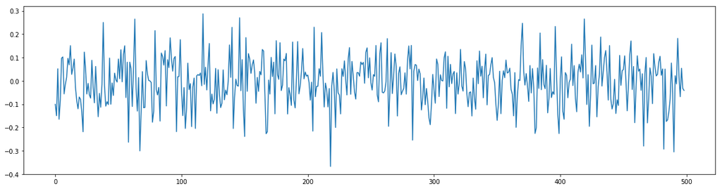

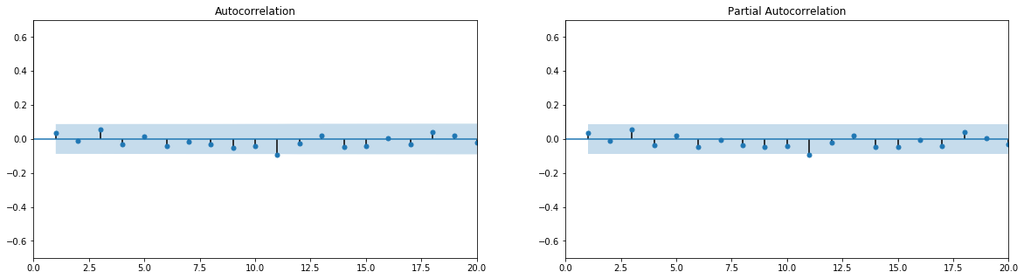

```python
show_acf_pacf(np.diff(dat.y3), lags_number=20)
```

$\Delta y_{3} \sim $ белый шум $\rightarrow y_{3, t} = y_{3, t-1} + \epsilon_{t} $

### Задача 4

Исходный файл с данными: income_csv.csv Имеются данные о ежеквартальном располагаемом доходе в Великобритании с первого квартала 1971 года по второй квартал 1985 года. Необходимо подобрать ARIMA модель, описывающую динамику ряда.

```python
dat = pd.read_csv('/Users/anton.andreytsev/Desktop/income.csv')
dat.columns = [i.lower() for i in dat.columns]
dat['year'] = dat.obs.apply(lambda x: int(x.split('Q')[0]))
dat['quarter'] = dat.obs.apply(lambda x: int(x.split('Q')[1]))
del dat['obs']
```

```python
dat.head()
```

|  | consum | income | year | quarter |
| --- | --- | --- | --- | --- |
| 0 | 8016 | 9014 | 1971 | 1 |
| 1 | 8798 | 9659 | 1971 | 2 |
| 2 | 9184 | 9848 | 1971 | 3 |
| 3 | 9755 | 10316 | 1971 | 4 |
| 4 | 9113 | 10254 | 1972 | 1 |

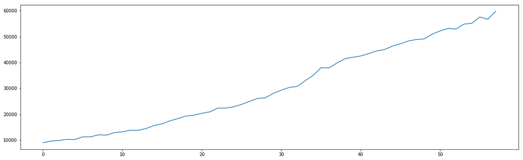

```python
plt.figure(figsize=(20, 6))
plt.plot(dat.income);
```

Ряд явно не стационарный

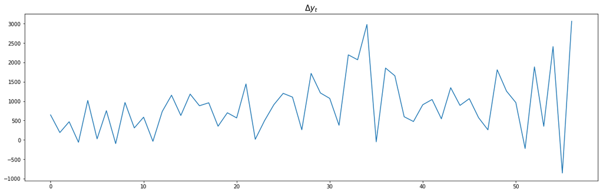

```python
plt.figure(figsize=(20, 6))
plt.plot(np.diff(dat.income));
plt.title('$\Delta y_{t}$', fontsize=15);
```

```python
print('Augmented Dickey-Fuller p-value:', stattools.adfuller(np.diff(dat.income, n=1), autolag='AIC', regression='c')[1])
print('Первые лаги не стационарны')
print('Augmented Dickey-Fuller p-value:', stattools.adfuller(np.diff(dat.income, n=2), autolag='AIC', regression='c')[1])
print('Вторые лаги стационарны')
```

```
Augmented Dickey-Fuller p-value: 0.21012547280652666
Первые лаги не стационарны
Augmented Dickey-Fuller p-value: 3.636215243164516e-18
Вторые лаги стационарны
```

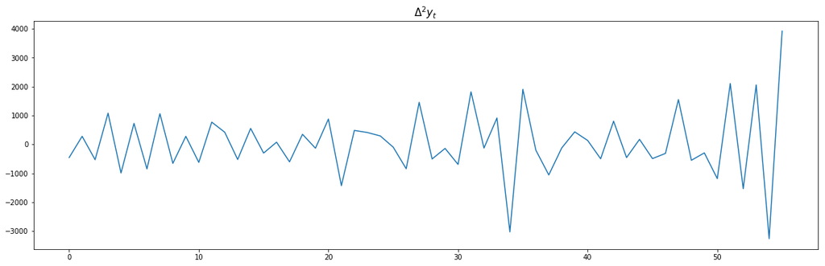

```python
plt.figure(figsize=(20, 6))
plt.plot(np.diff(dat.income, 2));
plt.title('$\Delta^2 y_{t}$', fontsize=15);
```

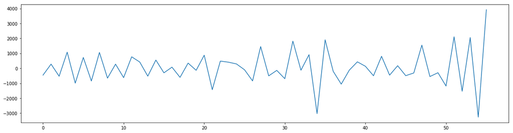

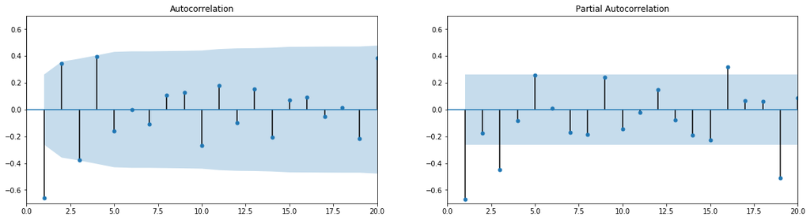

```python
show_acf_pacf(np.diff(dat.income, 2), lags_number=20)
```

Попробуем $\Delta^2 y_{t} \sim$ ARMA(4, 1)

```python
model_income = sm.tsa.statespace.SARIMAX(dat.income, order=(4, 2, 1)).fit()
print(model_income.summary())
```

```
                           Statespace Model Results
==============================================================================
Dep. Variable:                 income   No. Observations:                   58
Model:               SARIMAX(4, 2, 1)   Log Likelihood                -450.475
Date:                Fri, 12 Apr 2019   AIC                            912.950
Time:                        14:05:26   BIC                            925.102
Sample:                             0   HQIC                           917.661
                                 - 58
Covariance Type:                  opg
==============================================================================
                 coef    std err          z      P>|z|      [0.025      0.975]
------------------------------------------------------------------------------
ar.L1          0.0138      0.078      0.178      0.859      -0.138       0.166
ar.L2          0.1442      0.070      2.073      0.038       0.008       0.281
ar.L3         -0.0185      0.147     -0.127      0.899      -0.306       0.269
ar.L4          0.3492      0.088      3.956      0.000       0.176       0.522
ma.L1         -1.0000      0.178     -5.618      0.000      -1.349      -0.651
sigma2      4.162e+05   4.28e-07   9.73e+11      0.000    4.16e+05    4.16e+05
===================================================================================
Ljung-Box (Q):                       51.37   Jarque-Bera (JB):                 0.91
Prob(Q):                              0.11   Prob(JB):                         0.63
Heteroskedasticity (H):               1.32   Skew:                            -0.10
Prob(H) (two-sided):                  0.55   Kurtosis:                         3.59
===================================================================================

Warnings:
[1] Covariance matrix calculated using the outer product of gradients (complex-step).
[2] Covariance matrix is singular or near-singular, with condition number 3.5e+27. Standard errors may be unstable.
```

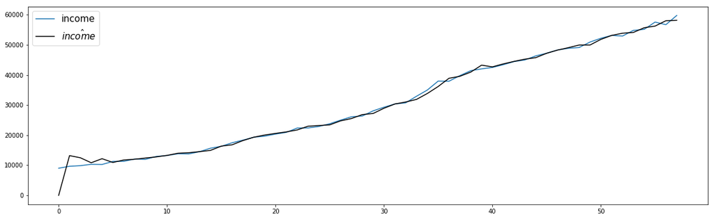

```python
plt.figure(figsize=(20, 6))
plt.plot(dat.income, label = 'income');
plt.plot(model_income.predict(), color='black', label='$\hat{income}$')
plt.legend(fontsize=15);
```

### Задача 5

На основе представленных в файле rus_income данных о динамике индекса реальных денежных доходов населения России: (а) подберите ARIMA модель, удачно описывающую динамику индекса реального дохода; (б) на основе полученной модели постройте прогноз индекса реального дохода на полгода (2 квартала) вперед (по сравнению с имеющимися в файле данными); (в) сравните прогнозные значения со значениями, наблюдавшимися на практике в рассматриваемые месяцы. (Примечание: фактическое значение индекса реальных денежных доходов населения в первом квартале 2008 года согласно данным Росстата составило 165.6.)

```python
dat = pd.read_excel('/Users/anton.andreytsev/Downloads/rus_income.xls', header=None).iloc[4:]
dat.columns = ['date', 'y']
dat.y = dat.y.astype(float)
```

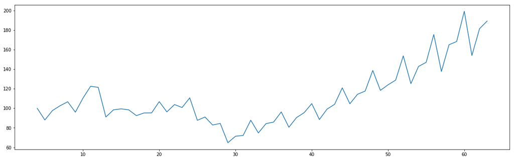

```python
plt.figure(figsize=(20, 6))
plt.plot(dat['y']);
```

```python
print('Augmented Dickey-Fuller p-value (diff = 1):', stattools.adfuller(np.diff(dat.y, n=1), autolag='AIC', regression='ct')[1])
print('KPSS p-value (diff = 1):', stattools.kpss(np.diff(dat.y, n=1), regression='ct')[1])
```

```
Augmented Dickey-Fuller p-value (diff = 1): 0.00019473561253586065
KPSS p-value (diff = 1): 0.045504685976904366
```

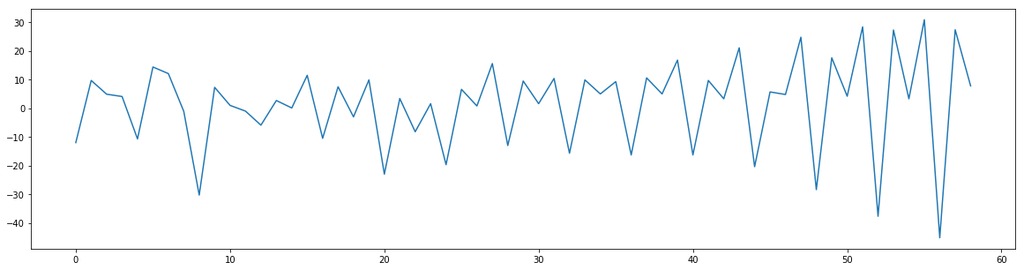

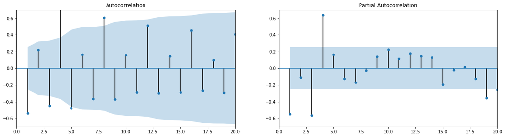

```python
show_acf_pacf(np.diff(dat.y, 1))
```

statsmodels умеет делать автоподбор параметров ARMA модели

```python
res = sm.tsa.arma_order_select_ic(np.diff(dat.y, 1), ic=['aic', 'bic'], trend='nc', max_ar=5, max_ma=5)
res
```

```
{'aic':             0           1           2           3           4           5
 0         NaN  478.657645  474.405321  471.926983  449.577733  446.763892
 1  478.227417  466.711637         NaN  452.542965  448.027753  455.125510
 2  479.766233  470.920779  480.973457  475.652381  448.699104  440.107055
 3  464.673507  453.991548  428.128663         NaN         NaN         NaN
 4         NaN  411.681815  412.874445  413.530141  415.529689  415.415547
 5         NaN  412.865427  414.219754  415.530011  416.376872  417.270410,
 'bic':             0           1           2           3           4           5
 0         NaN  482.812720  480.637933  480.237133  459.965420  459.229116
 1  482.382492  472.944249         NaN  462.930653  460.492978  469.668272
 2  485.998845  479.230929  491.361144  488.117605  463.241867  456.727354
 3  472.983656  464.379235  440.593887         NaN         NaN         NaN
 4         NaN  424.147039  427.417207  430.150441  434.227526  436.190922
 5         NaN  427.408189  430.840054  434.227848  437.152246  440.123322,
 'aic_min_order': (4, 1),
 'bic_min_order': (4, 1)}
```

```python
_ = sm.tsa.statespace.SARIMAX(dat.y, order=(4, 1, 1), enforce_invertibility=True, enforce_stationarity=False)
model_rus_income = _.fit(disp=-1)
print(model_rus_income.summary())
```

```
                           Statespace Model Results
==============================================================================
Dep. Variable:                      y   No. Observations:                   60
Model:               SARIMAX(4, 1, 1)   Log Likelihood                -182.678
Date:                Fri, 12 Apr 2019   AIC                            377.355
Time:                        17:16:24   BIC                            389.399
Sample:                             0   HQIC                           382.013
                                 - 60
Covariance Type:                  opg
==============================================================================
                 coef    std err          z      P>|z|      [0.025      0.975]
------------------------------------------------------------------------------
ar.L1         -0.2024      0.125     -1.618      0.106      -0.448       0.043
ar.L2         -0.1237      0.115     -1.073      0.283      -0.350       0.102
ar.L3         -0.1544      0.105     -1.474      0.141      -0.360       0.051
ar.L4          0.8762      0.104      8.416      0.000       0.672       1.080
ma.L1          0.2475      0.158      1.564      0.118      -0.063       0.558
sigma2        44.8711      9.596      4.676      0.000      26.064      63.678
===================================================================================
Ljung-Box (Q):                       33.91   Jarque-Bera (JB):                 2.39
Prob(Q):                              0.74   Prob(JB):                         0.30
Heteroskedasticity (H):               0.35   Skew:                             0.15
Prob(H) (two-sided):                  0.03   Kurtosis:                         3.97
===================================================================================

Warnings:
[1] Covariance matrix calculated using the outer product of gradients (complex-step).
```

```python
res_pred = model_rus_income.get_forecast(steps=10, alpha=0.05)
```

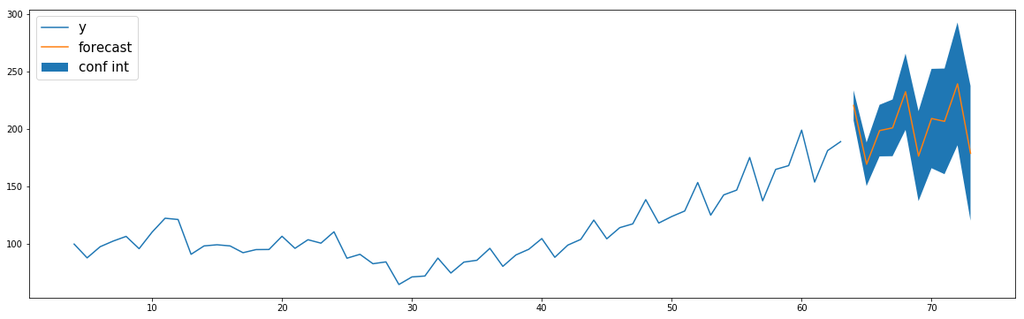

```python
plt.figure(figsize=(20, 6))
plt.plot(dat.y)
plt.plot(res_pred.predicted_mean, label='forecast')
plt.fill_between(res_pred.predicted_mean.index, res_pred.conf_int()['lower y'], res_pred.conf_int()['upper y'], label='conf int')
plt.legend(fontsize=15, loc=2);
```